# Sleep health

Derrick-Omai

2023-12-07

# R Markdown

```r
sleep <- read.csv("~/Desktop/Stats w:R/sleep.csv")
```

## a. Research Question

#### Does a higher quantity of sleep necessarily equal a higher quality of sleep?

A study about sleep is highly relevant to college students in promoting their wellness for several reasons. Below, I have touched on a few key points.

1.Academic Performance: Quality sleep is crucial for cognitive functions such as memory build up, problem-solving, and attention. Students who get sufficient and restful sleep are likely to perform better in their academic endeavors.

2.Learning and Retention: Sleep plays a vital role in the buildup of information learned during the day. Adequate sleep enhances the ability to retain and recall information, which is essential for college exams and assignments.

3.Mental Health: Lack of sleep is linked to increased stress, anxiety, and depression. College students often face high levels of stress due to academic pressures, and prioritizing sleep can help manage these mental health challenges.

4.Daytime Functioning: Lack of sleep can lead to daytime sleepiness and decreased alertness. This can negatively impact class attendance, participation, and the overall ability to engage in academic and social activities effectively.

In summary, a study about sleep is relevant to college students as it directly impacts their academic performance, mental and physical health, and overall well-being. Promoting good sleep habits can contribute to a more successful and fulfilling college experience.

## b. Background Information

The relationship between sleep quantity and sleep quality is a topic of interest in the field of sleep science. While it is commonly believed that a higher quantity of sleep leads to a higher quality of sleep, this is not always the case. According to the National Sleep Foundation, sleep quality refers to how restorative your sleep feels, while sleep quantity refers to the number of hours you sleep.

A study conducted by MIT professors found that there is a strong relationship between students’ grades and how much sleep they’re getting. The study also found that the timing of sleep and the consistency of sleep habits make a big difference. Even relatively small differences in the duration, timing, and consistency of students’ sleep may have significant effects on course test results. Another study found that sleep quality was correlated with greater perceived psychological and emotional wellness, while greater sleep duration reflected better social and overall perceived wellness.

However, the relationship between sleep quantity and sleep quality is not always straightforward. A study published in PLOS ONE found that sleep quality is the strongest predictor of all sleep variables in explaining both within-person and between-person differences in quality-of-life indicators. The study examined the effect of changes in sleep duration, sleep quality, and social jet lag on satisfaction with life, happiness, work stress, subjective health, and well-being. The study found that although sleep duration and timing are important, sleep quality is the most important factor in determining quality of life.

According to Sleep Advisor, sleep quality is affected by both internal and external factors. Internal factors include physical pain, stress, mental health issues, snoring, and sleep disorders. External factors include light, jet lag, medications, sleep environment, sleep schedule, caffeine and alcohol, and certain foods.

In addition, according to a study conducted in a Singapore residential college, there is a relationship between sleep and academic performance. The study found that the timing of sleep and the consistency of sleep habits make a big difference. Even relatively small differences in the duration, timing, and consistency of students’ sleep may have significant effects on course test results. However, the relationship between sleep quantity and sleep quality is not always straightforward. Sleep quality is the most important factor in determining the restorative value of sleep. College students should aim to get enough sleep and maintain a consistent sleep schedule to ensure that they are well-rested.

#### Our Dataset:

It includes details such as gender, age, occupation, sleep duration, quality of sleep, physical activity level, stress levels, BMI category, blood pressure, heart rate, daily steps, and the presence or absence of sleep disorders.

#### Our Chosen Variables:

Sleep Duration (hours): The number of hours the person sleeps per day.

Quality of Sleep (scale: 1-10): A subjective rating of the quality of sleep, ranging from 1 to 10.

## c. Desciptive statistics

```r
summary(sleep)
```

```
##    Person.ID         Gender               Age         Occupation
##  Min.   :  1.00   Length:374         Min.   :27.00   Length:374
##  1st Qu.: 94.25   Class :character   1st Qu.:35.25   Class :character
##  Median :187.50   Mode  :character   Median :43.00   Mode  :character
##  Mean   :187.50                      Mean   :42.18
##  3rd Qu.:280.75                      3rd Qu.:50.00
##  Max.   :374.00                      Max.   :59.00
##  Sleep.Duration  Quality.of.Sleep Physical.Activity.Level  Stress.Level
##  Min.   :5.800   Min.   :4.000    Min.   :30.00           Min.   :3.000
##  1st Qu.:6.400   1st Qu.:6.000    1st Qu.:45.00           1st Qu.:4.000
##  Median :7.200   Median :7.000    Median :60.00           Median :5.000
##  Mean   :7.132   Mean   :7.313    Mean   :59.17           Mean   :5.385
##  3rd Qu.:7.800   3rd Qu.:8.000    3rd Qu.:75.00           3rd Qu.:7.000
##  Max.   :8.500   Max.   :9.000    Max.   :90.00           Max.   :8.000
##  BMI.Category       Blood.Pressure     Blood.pressure.systolic
##  Length:374         Length:374         Min.   :115.0
##  Class :character   Class :character   1st Qu.:125.0
##  Mode  :character   Mode  :character   Median :130.0
##                                        Mean   :128.6
##                                        3rd Qu.:135.0
##                                        Max.   :142.0
##  Blood.pressure.diastolic   Heart.Rate     Daily.Steps    Sleep.Disorder
##  Min.   :75.00            Min.   :65.00   Min.   : 3000   Length:374
##  1st Qu.:80.00            1st Qu.:68.00   1st Qu.: 5600   Class :character
##  Median :85.00            Median :70.00   Median : 7000   Mode  :character
##  Mean   :84.65            Mean   :70.17   Mean   : 6817
##  3rd Qu.:90.00            3rd Qu.:72.00   3rd Qu.: 8000
##  Max.   :95.00            Max.   :86.00   Max.   :10000
```

Since we are working with two quantitative datasets, we will be utilizing a correlation test and a scatterplot.

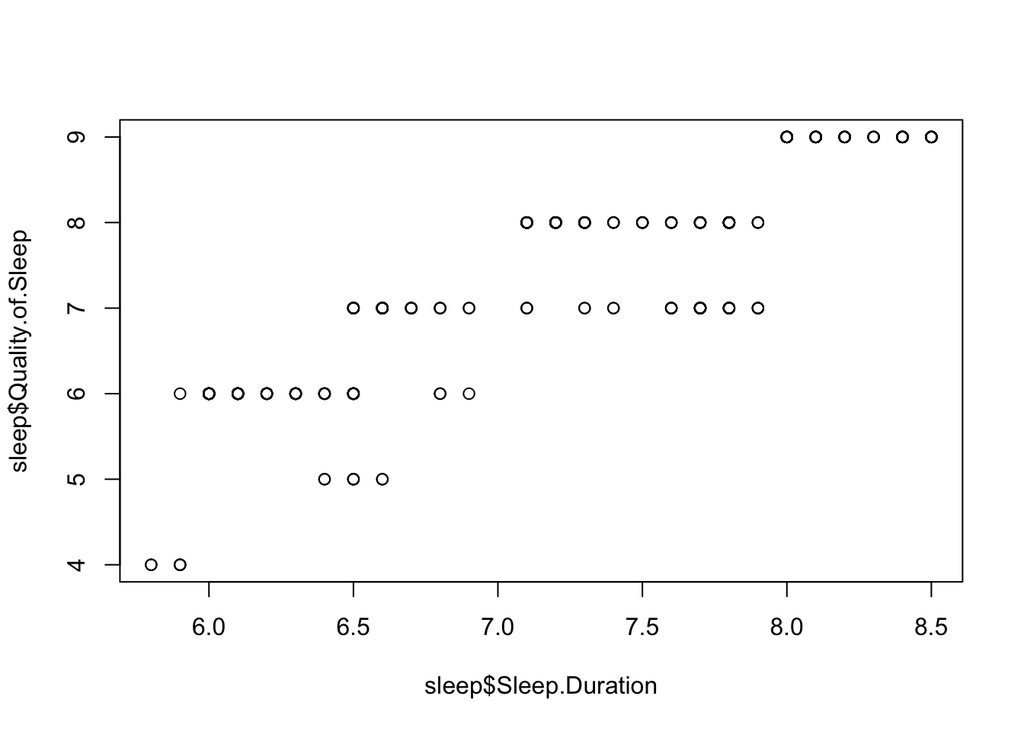

```r
plot(sleep$Sleep.Duration, sleep$Quality.of.Sleep)
```

Looking at the scatterplot, what first jumps out are the lineal clusters. A tight cluster usually indicates a higher relationship between the variables.

There are no outliers.

The graph also shows a positive trend. This is because as Sleep duration increases, so does the quality of sleep.

```r
linmod  = lm(sleep$Sleep.Duration~sleep$Quality.of.Sleep)
summary(linmod)
```

```
##
## Call:
## lm(formula = sleep$Sleep.Duration ~ sleep$Quality.of.Sleep)
##
## Residuals:
##      Min       1Q   Median       3Q      Max
## -0.46132 -0.33552 -0.06132  0.26448  0.95158
##
## Coefficients:
##                        Estimate Std. Error t value Pr(>|t|)
## (Intercept)             2.83871    0.11977   23.70   <2e-16 ***
## sleep$Quality.of.Sleep  0.58710    0.01616   36.32   <2e-16 ***
## ---
## Signif. codes:  0 '***' 0.001 '**' 0.01 '*' 0.05 '.' 0.1 ' ' 1
##
## Residual standard error: 0.3736 on 372 degrees of freedom
## Multiple R-squared:  0.7801, Adjusted R-squared:  0.7795
## F-statistic:  1319 on 1 and 372 DF,  p-value: < 2.2e-16
```

We are using the lm() function in R because it is used for fitting linear models. We further utilize it to model and understand the relationship between our variables.

Multiple R(squared) = Coefficient of determination.

The adjusted R-squared value of 0.7795 is similar to the multiple R-squared value, but it takes into account the number of predictors in the model.

The multiple R-squared value of 0.7801 indicates that 78.01% of the variation in Sleep.Duration can be explained by the variation in Quality.of.Sleep

The t-value of 36.32 with 372 degrees of freedom indicates that the coefficient for Quality.of.Sleep is statistically significant

The p-value of < 2.2e-16 indicates that the probability of observing such a strong association between Sleep Duration and Sleep Quality by chance is very low.

## d. Hypothesis test.

```r
cor.test(sleep$Sleep.Duration, sleep$Quality.of.Sleep)
```

```
##
##  Pearson's product-moment correlation
##
## data:  sleep$Sleep.Duration and sleep$Quality.of.Sleep
## t = 36.324, df = 372, p-value < 2.2e-16
## alternative hypothesis: true correlation is not equal to 0
## 95 percent confidence interval:
##  0.8587162 0.9036825
## sample estimates:
##      cor
## 0.883213
```

p-value = < 2.2e-16

Since p-val = < 2.2e-16. Which is less than .05, it means that the data is statistically significant.

$H_O: p = 0$ (no linear relationship)

if p-val is <.05, reject $H_0$

Based on the statistics, there is sufficient evidence to indicate that there is a significant correlation between quantity of sleep and quality of sleep.

However, it’s important to note that correlation does not imply causation. There may be other factors that affect the quality of sleep, and further research is needed to establish a causal relationship.

The 95% confidence interval for the correlation coefficient is (0.8587162, 0.9036825). This means that we are 95% confident that the true correlation coefficient lies between 0.8587162 and 0.9036825 .

The test statistic is 36.324 with 372 degrees of freedom.

#### Effect Size

```r
lob = cor(sleep$Sleep.Duration, sleep$Quality.of.Sleep, use = "pairwise.complete.obs")
abs(lob)
```

```
## [1] 0.883213
```

The above function ‘cor()’ gives us the correlation coefficient. Its output ranges from -1 to 1. 1: represents a perfect positive linear relationship, while -1: represents a perfect negative linear relationship. 0: indicates no linear relationship.

Correlation Coefficient Value: 0.883 is very close to 1 indicating a strong, positive linear relationship.

Direction: 0.883 is a positive value, meaning as sleep duration increases, so does the quality of sleep.

The strength of the correlation can be interpreted as follows :

0.00-0.19: Very weak correlation

0.20-0.39: Weak correlation

0.40-0.59: Moderate correlation

0.60-0.79: Strong correlation

0.80-1.00: Very strong correlation

Since the correlation coefficient is 0.883213, we can conclude that there is a strong positive correlation between Sleep.Duration and Quality.of.Sleep .

## e. Conclusion

In summation, the motive of this study was to examine the link between the duration of sleep and the quality of sleep. To be more specific, whether a higher quality of sleep necessarily stems from having a higher quantity of sleep. Understanding the difficulties that students go through with juggling multiple assignments and for some, athletic demands. This study aimed to look at if they necessarily need that “8 hours” to have a healthy, beneficial, and restorative sleep.

The background information informed us that the relationship between quality and quantity of sleep is not so straightforward. Other factors such as happiness, stress and well-being may play a part.

For the hypothesis test, we used the correlation test to test the association between Sleep.Duration and Quality.of.sleep. The test results indicated that as sleep duration increases, so does the quality of sleep.

We employed the effect size to measure the strength of the relationship between quantity of sleep and quality of sleep. We got a correlation coefficient of 0.883213 which indicates a strong positive correlation between the two variables. However, we were keen to note that there may be other factors that affect the quality of sleep, and further research is needed to establish a causal relationship.

In conclusion, while the study did not provide an incontestable conclusion for the relationship between sleep quality and sleep duration, it illuminated that there may be other minor factors behind the scenes that ultimately have a major effect. To shed more light, It opened a door for potential research into factors such as happiness, satisfaction with life, sleep environment and stress levels, and how much of a role they play in one’s quality of sleep.

## f. Citations:

- Zwarensteyn, Jill. “12 Factors Affecting Sleep and Your Sleep Quality.” Sleep Advisor, 4 Dec. 2023, www.sleepadvisor.org/sleep-factors/.
- SleepandYou. “What Is Sleep Quality?” National Sleep Foundation, 1 Nov. 2020, www.thensf.org/what-is-sleep-quality/.
- Kudrnáčová, Michaela, and Aleš Kudrnáč. “Better Sleep, Better Life? Testing the Role of Sleep on Quality of Life.” PLOS ONE, Public Library of Science, journals.plos.org/plosone/article?id=10.1371%2Fjournal.pone.0282085. Accessed 8 Dec. 2023.
- Armand, Marc A., et al. “Sleep, Well-Being and Academic Performance: A Study in a Singapore Residential College.” Frontiers, Frontiers, 27 Apr. 2021, www.frontiersin.org/articles/10.3389/fpsyg.2021.672238/full.